# R Notebook

# Importar Data

```r
library(rattle)
library(cluster)
```

# Importar Data

```r
data(wine)
head(wine)
```

|  | Type | Alcohol | Malic | Ash | Alcalinity | Magnesium | Phenols | Flavanoids | Nonflavanoids | Proanthocyanins | Color | Hue | Dilution | Proline |
| --- | --- | --- | --- | --- | --- | --- | --- | --- | --- | --- | --- | --- | --- | --- |
| 1 | 1 | 14.23 | 1.71 | 2.43 | 15.6 | 127 | 2.80 | 3.06 | 0.28 | 2.29 | 5.64 | 1.04 | 3.92 | 1065 |
| 2 | 1 | 13.20 | 1.78 | 2.14 | 11.2 | 100 | 2.65 | 2.76 | 0.26 | 1.28 | 4.38 | 1.05 | 3.40 | 1050 |
| 3 | 1 | 13.16 | 2.36 | 2.67 | 18.6 | 101 | 2.80 | 3.24 | 0.30 | 2.81 | 5.68 | 1.03 | 3.17 | 1185 |
| 4 | 1 | 14.37 | 1.95 | 2.50 | 16.8 | 113 | 3.85 | 3.49 | 0.24 | 2.18 | 7.80 | 0.86 | 3.45 | 1480 |
| 5 | 1 | 13.24 | 2.59 | 2.87 | 21.0 | 118 | 2.80 | 2.69 | 0.39 | 1.82 | 4.32 | 1.04 | 2.93 | 735 |
| 6 | 1 | 14.20 | 1.76 | 2.45 | 15.2 | 112 | 3.27 | 3.39 | 0.34 | 1.97 | 6.75 | 1.05 | 2.85 | 1450 |

O K-mean visa agrupar as observações de modo a minimizar a soma dos quadrados dentro do cluster (WCSS). No caso, o número de clusters a ser utilizado é 3.

# Verificar as categorias

```r
#calcular o número ótimo de clusters
#fviz_nbclust(wine, kmeans, method = "gap_stat")
# To standarize the variables
wine.stand <- scale(wine[-1])
#cl <- round(sqrt(nrow(wine)/2))
#cl
# kmeans - divide in 3 clusters
k.means.fit <- kmeans(wine.stand, 3)
```

Em attributes, são apresentados todos os elementos do cluster:

```r
# Overview - all the elements of the cluster
attributes(k.means.fit)
```

```
$names
[1] "cluster"      "centers"      "totss"        "withinss"     "tot.withinss"
[6] "betweenss"    "size"         "iter"         "ifault"

$class
[1] "kmeans"
```

Cálculo dos centróides:

```r
# Centroids:
k.means.fit$centers
```

```
     Alcohol      Malic        Ash Alcalinity   Magnesium     Phenols  Flavanoids
1 -0.9234669 -0.3929331 -0.4931257  0.1701220 -0.49032869 -0.07576891  0.02075402
2  0.1644436  0.8690954  0.1863726  0.5228924 -0.07526047 -0.97657548 -1.21182921
3  0.8328826 -0.3029551  0.3636801 -0.6084749  0.57596208  0.88274724  0.97506900
  Nonflavanoids Proanthocyanins      Color        Hue   Dilution    Proline
1   -0.03343924      0.05810161 -0.8993770  0.4605046  0.2700025 -0.7517257
2    0.72402116     -0.77751312  0.9388902 -1.1615122 -1.2887761 -0.4059428
3   -0.56050853      0.57865427  0.1705823  0.4726504  0.7770551  1.1220202
```

Agrupamento das observações em cada cluster, de acordo com o centróide:

```r
# Clusters:
k.means.fit$cluster
```

```
  [1] 3 3 3 3 3 3 3 3 3 3 3 3 3 3 3 3 3 3 3 3 3 3 3 3 3 3 3 3 3 3 3 3 3 3 3 3 3 3 3 3 3
 [42] 3 3 3 3 3 3 3 3 3 3 3 3 3 3 3 3 3 3 1 1 2 1 1 1 1 1 1 1 1 1 1 1 3 1 1 1 1 1 1 1 1
 [83] 1 2 1 1 1 1 1 1 1 1 1 1 1 3 1 1 1 1 1 1 1 1 1 1 1 1 1 1 1 1 1 1 1 1 1 1 2 1 1 3 1
[124] 1 1 1 1 1 1 1 2 2 2 2 2 2 2 2 2 2 2 2 2 2 2 2 2 2 2 2 2 2 2 2 2 2 2 2 2 2 2 2 2 2
[165] 2 2 2 2 2 2 2 2 2 2 2 2 2 2
```

Sumário do número de observações por cluster:

```r
# Cluster size:
k.means.fit$size
```

```
[1] 65 51 62
```

# Clustering pelo Método de Elbow

Pelo Método de Elbow, podemos determinar o valor do parâmetro k plotando um gráfico da porcentagem da variância em relação ao número de clusters. No caso, analisando 6 clusters, escolhemos o valor 3 porque a partir desse valor ocorre prejuízo da explicação da variância pelos clusters.

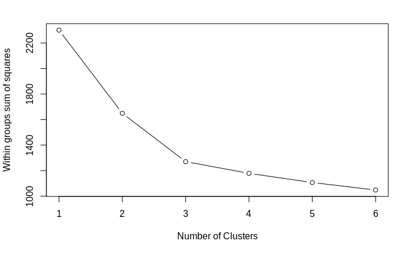

```r
wssplot <- function(data, nc=15, seed=1234){
  wss <- (nrow(data)-1)*sum(apply(data,2,var))
  for (i in 2:nc){
    set.seed(seed)
    wss[i] <- sum(kmeans(data, centers=i)$withinss)}
  plot(1:nc, wss, type="b", xlab="Number of Clusters",
       ylab="Within groups sum of squares")}
wssplot(wine.stand, nc=6)
```

Utilizamos a library Cluster para representar o agrupamento dos clusters em 2D.

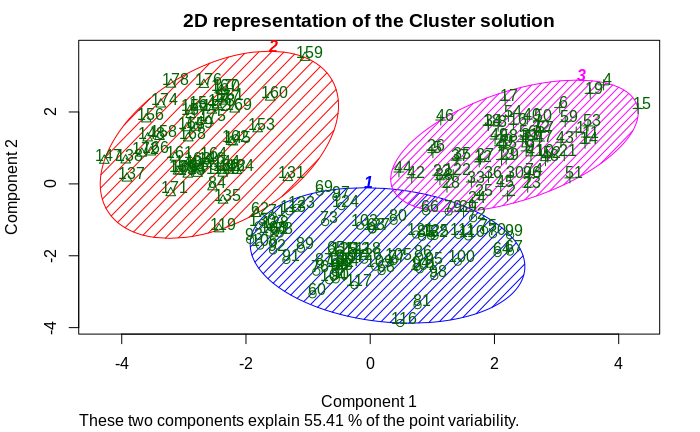

```r
clusplot(wine.stand, k.means.fit$cluster, main='2D representation of the Cluster solution',
         color=TRUE, shade=TRUE,
         labels=2, lines=0)
```

Matriz de Confusão para avaliar a perfomance do agrupamento em clusters:

```r
table(wine[,1],k.means.fit$cluster)
```

[output not shown]

# Clustering utilizando a distância Euclidiana

É utilizada a distância Euclidiana como algoritmo para calcular o agrupamento dos clusters. A escolha do método altera o cálculo das distâncias e o agrupamento em clusters.

```r
d <- dist(wine.stand, method = "euclidean") # Euclidean distance matrix.
```

```r
H.fit <- hclust(d, method="ward.D2")
```

O output do cluster pode ser visualizado em um dendograma:

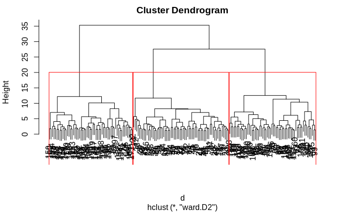

```r
plot(H.fit) # display dendogram
groups <- cutree(H.fit, k=3) # cut tree into 5 clusters
# draw dendogram with red borders around the 5 clusters
rect.hclust(H.fit, k=3, border="red")
```

Matriz de Confusão para analisar o agrupamento:

```r
table(wine[,1],groups)
```

```
   groups
     1  2  3
  1 59  0  0
  2  5 58  8
  3  0  0 48
```

# Study Case I: European Protein Consumtion

Consideramos o número de países n=25 e o consumo de proteínas (%) por cada fonte alimentícia:

```r
url = 'http://www.biz.uiowa.edu/faculty/jledolter/DataMining/protein.csv'
food <- read.csv(url)
head(food)
```

|  | Country | RedMeat | WhiteMeat | Eggs | Milk | Fish | Cereals | Starch | Nuts | Fr.Veg |
| --- | --- | --- | --- | --- | --- | --- | --- | --- | --- | --- |
| 1 | Albania | 10.1 | 1.4 | 0.5 | 8.9 | 0.2 | 42.3 | 0.6 | 5.5 | 1.7 |
| 2 | Austria | 8.9 | 14.0 | 4.3 | 19.9 | 2.1 | 28.0 | 3.6 | 1.3 | 4.3 |
| 3 | Belgium | 13.5 | 9.3 | 4.1 | 17.5 | 4.5 | 26.6 | 5.7 | 2.1 | 4.0 |
| 4 | Bulgaria | 7.8 | 6.0 | 1.6 | 8.3 | 1.2 | 56.7 | 1.1 | 3.7 | 4.2 |
| 5 | Czechoslovakia | 9.7 | 11.4 | 2.8 | 12.5 | 2.0 | 34.3 | 5.0 | 1.1 | 4.0 |
| 6 | Denmark | 10.6 | 10.8 | 3.7 | 25.0 | 9.9 | 21.9 | 4.8 | 0.7 | 2.4 |

O primeiro agrupamento em clusters é realizado somente em Red Meat e White Meat (p=2) e k=3 clusters:

```r
set.seed(123456789) ## to fix the random starting clusters
grpMeat <- kmeans(food[,c("WhiteMeat","RedMeat")], centers=3, nstart=10)
grpMeat
```

```
K-means clustering with 3 clusters of sizes 12, 5, 8

Cluster means:
  WhiteMeat   RedMeat
1  4.658333  8.258333
2  9.000000 15.180000
3 12.062500  8.837500

Clustering vector:
 [1] 1 3 2 1 3 3 3 1 2 1 3 2 1 3 1 3 1 1 1 1 2 2 1 3 1

Within cluster sum of squares by cluster:
[1] 69.85833 35.66800 39.45750
 (between_SS / total_SS =  75.7 %)

Available components:

[1] "cluster"      "centers"      "totss"        "withinss"     "tot.withinss"
[6] "betweenss"    "size"         "iter"         "ifault"
```

É realizado o agrupamento dos dois parâmetros Red Meat e White Meat como um único “grupo carne”:

```r
## list of cluster assignments
o=order(grpMeat$cluster)
data.frame(food$Country[o],grpMeat$cluster[o])
```

[output not shown]

Plotamos um Scatterplot representando graficamente a disposição em clusters segundo o consumo do “grupo carne” (por país):

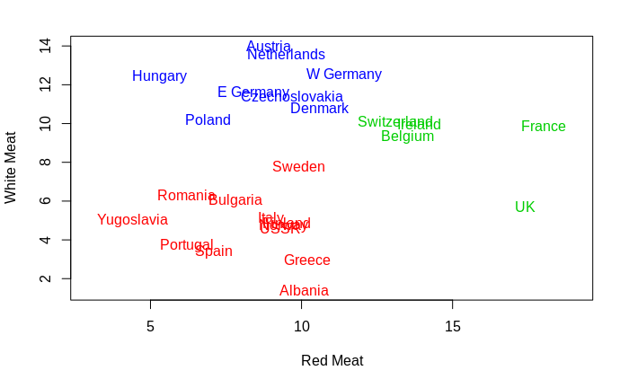

```r
plot(food$Red, food$White, type="n", xlim=c(3,19), xlab="Red Meat", ylab="White Meat")
text(x=food$Red, y=food$White, labels=food$Country,col=grpMeat$cluster+1)
```

```r
## same analysis, but now with clustering on all
## protein groups change the number of clusters to 7
set.seed(123456789)
grpProtein <- kmeans(food[,-1], centers=7, nstart=10)
o=order(grpProtein$cluster)
data.frame(food$Country[o],grpProtein$cluster[o])
```

| food.Country.o. | grpProtein.cluster.o. |
| --- | --- |
| Denmark | 1 |
| Finland | 1 |
| Norway | 1 |
| Sweden | 1 |
| Austria | 2 |
| E Germany | 2 |
| Netherlands | 2 |
| W Germany | 2 |
| Portugal | 3 |
| Spain | 3 |

[output cut: 15 more lines]

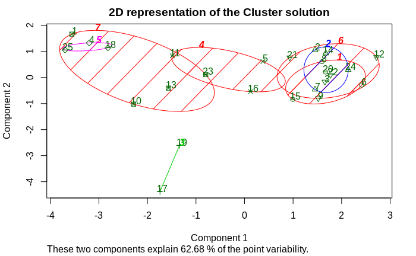

```r
library(cluster)
clusplot(food[,-1], grpProtein$cluster, main='2D representation of the Cluster solution', color=TRUE, shade=TRUE, labels=2, lines=0)
```

Alternativamente, podemos implementar uma abordagem hierárquica. Usamos a função agnes no cluster de pacote. O argumento diss = FALSE indica que usamos a matriz de dissimilaridade que está sendo calculada a partir dos dados brutos. O argumento metric = “euclidiano” indica que usamos a distância euclidiana. Nenhuma padronização é usada e a função de ligação é a ligação “média”.

### matriz de dissimilaridade?

### Leitura de dendograma ?

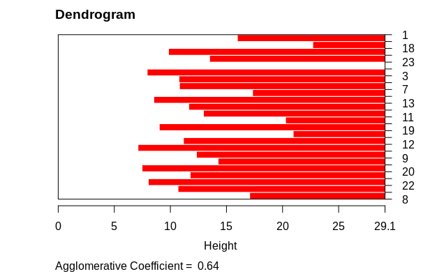

```r
foodagg=agnes(food,diss=FALSE,metric="euclidian")
plot(foodagg, main='Dendrogram') ## dendrogram
```

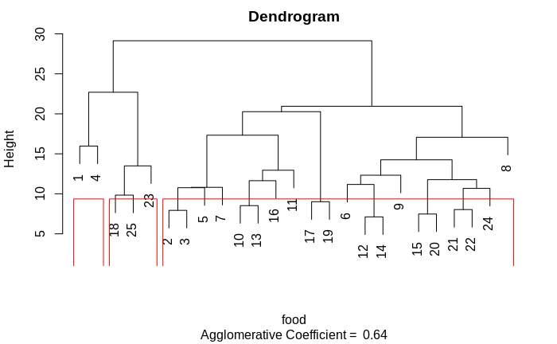

```r
groups <- cutree(foodagg, k=3) # cut tree into 3 clusters
rect.hclust(foodagg, k=3, border="red")
```

# Study Case II: Customer Segmentation

Agrupamento de Clientes de acordo com suas características, visando atender melhor às suas necessidades.

```r
#load file
path = "/media/angelica/Dados/Dev/GitHub/DataScience Courses/Kmeans"
```

```r
offers<-read.table("/media/angelica/Dados/Dev/GitHub/DataScience Courses/Kmeans/offers.csv", sep = ',', header=T)
head(offers)
```

|  | Offer | Campaign | Varietal | Minimum.Qty..kg. | Discount.... | Origin | Past.Peak |
| --- | --- | --- | --- | --- | --- | --- | --- |
| 1 | 1 | January | Malbec | 72 | 56 | France | FALSE |
| 2 | 2 | January | Pinot Noir | 72 | 17 | France | FALSE |
| 3 | 3 | February | Espumante | 144 | 32 | Oregon | TRUE |
| 4 | 4 | February | Champagne | 72 | 48 | France | TRUE |
| 5 | 5 | February | Cabernet Sauvignon | 144 | 44 | New Zealand | TRUE |
| 6 | 6 | March | Prosecco | 144 | 86 | Chile | FALSE |

```r
transactions<-read.table("/media/angelica/Dados/Dev/GitHub/DataScience Courses/Kmeans/transactions.csv", sep = ',', header=T)
head(transactions)
```

|  | Customer.Last.Name | Offer |
| --- | --- | --- |
| 1 | Smith | 2 |
| 2 | Smith | 24 |
| 3 | Johnson | 17 |
| 4 | Johnson | 24 |
| 5 | Johnson | 26 |
| 6 | Williams | 18 |

É realizada uma matriz de transação, a partir do cruzamento dos dados das ofertas realizadas com o histórico de transação de cada cliente.

```r
library(reshape)
pivot<-melt(transactions[1:2])
```

```r
## Using CustomerLastName as id variables
pivot<-(cast(pivot,value~Customer.Last.Name,fill=0,fun.aggregate=function(x) length(x)))
pivot<-cbind(offers,pivot[-1])
```

Geração da pivot.table com as informações de oferta x transação:

Oferta: colunas Transação: linha

```r
# write.csv(file="pivot.csv",pivot) # to save your data
cluster.data<-pivot[,8:length(pivot)]
cluster.data<-t(cluster.data)
head(cluster.data)
```

```
         1 2 3 4 5 6 7 8 9 10 11 12 13 14 15 16 17 18 19 20 21 22 23 24 25 26 27 28 29
Adams    0 0 0 0 0 0 0 0 0  0  0  0  0  0  0  0  0  1  0  0  0  0  0  0  0  0  0  0  1
Allen    0 0 0 0 0 0 0 0 1  0  0  0  0  0  0  0  0  0  0  0  0  0  0  0  0  0  1  0  0
Anderson 0 0 0 0 0 0 0 0 0  0  0  0  0  0  0  0  0  0  0  0  0  0  0  1  0  1  0  0  0
Bailey   0 0 0 0 0 0 1 0 0  0  0  0  0  0  0  0  0  0  0  0  0  0  0  0  0  0  0  0  0
Baker    0 0 0 0 0 0 1 0 0  1  0  0  0  0  0  0  0  0  1  0  0  0  0  0  0  0  0  0  0
Barnes   0 0 0 0 0 0 0 0 0  1  0  0  0  0  0  0  0  0  0  0  1  1  0  0  0  0  0  0  0
         30 31 32
Adams     1  0  0
Allen     0  0  0
Anderson  0  0  0
Bailey    1  0  0
Baker     0  1  0
Barnes    0  1  0
```

Utilizaremos k = 4 clusters inicialmente, selecionado de forma aleatória.

Precisamos calcular a distância de cada cliente da média do cluster. Para fazer isso, poderíamos usar muitas distâncias / índice de dissimilaridade, um dos quais é a dissimilaridade de Gower.

```r
library(cluster)
D=daisy(cluster.data, metric='gower')
```

```
binary variable(s) 1, 2, 3, 4, 5, 6, 7, 8, 9, 10, 11, 12, 13, 14, 15, 16, 17, 18, 19, 20, 21, 22, 23, 24, 25, 26, 27, 28, 29, 30, 31, 32 treated as interval scaled
```

Após a criação de uma matriz de distância, implementamos um procedimento de agrupamento hierárquico de Ward:

```r
H.fit <- hclust(D, method="ward.D2")
```

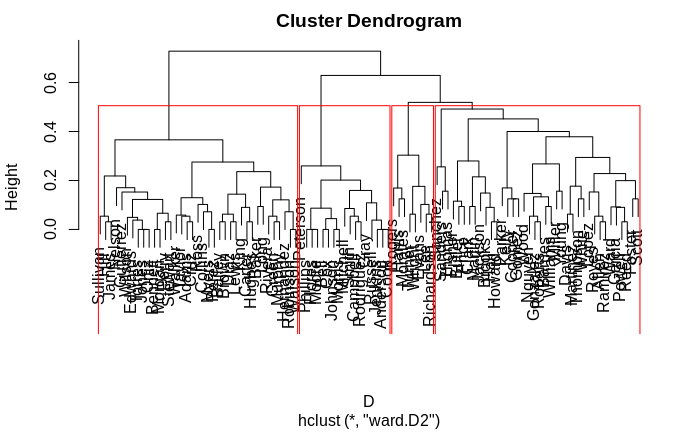

```r
plot(H.fit) # display dendrogram
groups <- cutree(H.fit, k=4) # cut tree into 4 clusters
rect.hclust(H.fit, k=4, border="red")
```

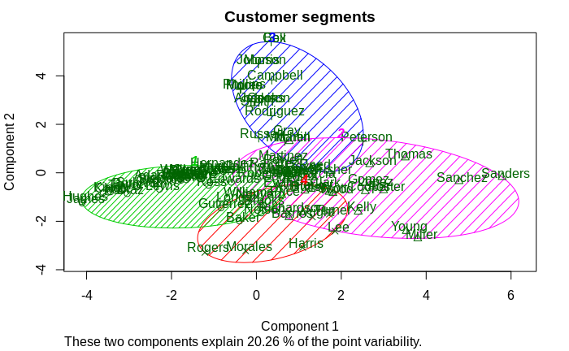

```r
# 2D representation of the Segmentation:
clusplot(cluster.data, groups, color=TRUE, shade=TRUE,
         labels=2, lines=0, main= 'Customer segments')
```

Para obter os melhores negócios, é necessário manipulação de dados. Primeiro, precisamos combinar nossos clusters e transações. Notavelmente, os comprimentos das “tabelas” que mantêm transações e clusters são diferentes. Portanto, precisamos de uma maneira de mesclar os dados. então usamos a função merge () e damos às nossas colunas nomes adequados:

```r
cluster.deals<-merge(transactions[1:2],groups,by.x = "Customer.Last.Name", by.y = "row.names")
colnames(cluster.deals)<-c("Name","Offer","Cluster")
head(cluster.deals)
```

|  | Name | Offer | Cluster |
| --- | --- | --- | --- |
| 1 | Adams | 18 | 1 |
| 2 | Adams | 29 | 1 |
| 3 | Adams | 30 | 1 |
| 4 | Allen | 9 | 2 |
| 5 | Allen | 27 | 2 |
| 6 | Anderson | 24 | 3 |

Em seguida, queremos repetir o processo de dinamização para obter Ofertas em linhas e Clusters em colunas, contando o número total de transações para cada cluster. Assim que tivermos nossa pivot-table, iremos mesclá-la com a tabela de dados de ofertas como fizemos antes:

```r
# Get top deals by cluster
cluster.pivot<-melt(cluster.deals,id=c("Offer","Cluster"))
cluster.pivot<-cast(cluster.pivot,Offer~Cluster,fun.aggregate=length)
cluster.topDeals<-cbind(offers,cluster.pivot[-1])
head(cluster.topDeals)
```

|  | Offer | Campaign | Varietal | Minimum.Qty..kg. | Discount.... | Origin | Past.Peak | 1 | 2 | 3 | 4 |
| --- | --- | --- | --- | --- | --- | --- | --- | --- | --- | --- | --- |
| 1 | 1 | January | Malbec | 72 | 56 | France | FALSE | 0 | 8 | 2 | 0 |
| 2 | 2 | January | Pinot Noir | 72 | 17 | France | FALSE | 0 | 3 | 7 | 0 |
| 3 | 3 | February | Espumante | 144 | 32 | Oregon | TRUE | 2 | 1 | 0 | 3 |
| 4 | 4 | February | Champagne | 72 | 48 | France | TRUE | 1 | 7 | 0 | 4 |
| 5 | 5 | February | Cabernet Sauvignon | 144 | 44 | New Zealand | TRUE | 0 | 4 | 0 | 0 |
| 6 | 6 | March | Prosecco | 144 | 86 | Chile | FALSE | 1 | 5 | 0 | 6 |

# Study Case III: Social Network Clustering Analysis

Para esta análise, usaremos um conjunto de dados que representa uma amostra aleatória de 30.000 alunos do ensino médio dos EUA que tinham perfis em uma rede social conhecida de 2006 a 2009.

Das 500 primeiras palavras que aparecem em todas as páginas, 36 palavras foram escolhidas para representar cinco categorias de interesses, a saber: atividades extracurriculares, moda, religião, romance e comportamento anti-social. As 36 palavras incluem termos como futebol, sexy, beijo, bíblia, compras, morte e drogas. O conjunto de dados final indica, para cada pessoa, quantas vezes cada palavra apareceu no perfil da pessoa.

```r
teens <- read.csv("https://raw.githubusercontent.com/brenden17/sklearnlab/master/facebook/snsdata.csv")
head(teens,3)
```

|  | gradyear | gender | age | friends | basketball | football | soccer | softball | volleyball | swimming | cheerleading | baseball | tennis | sports | cute | sex | sexy | hot | kissed | dance | band | marching | music | rock | god | church | jesus | bible | hair | … |
| --- | --- | --- | --- | --- | --- | --- | --- | --- | --- | --- | --- | --- | --- | --- | --- | --- | --- | --- | --- | --- | --- | --- | --- | --- | --- | --- | --- | --- | --- | --- |
| 1 | 2006 | M | 18.982 | 7 | 0 | 0 | 0 | 0 | 0 | 0 | 0 | 0 | 0 | 0 | 0 | 0 | 0 | 0 | 0 | 1 | 0 | 0 | 0 | 0 | 0 | 0 | 0 | 0 | 0 | … |
| 2 | 2006 | F | 18.801 | 0 | 0 | 1 | 0 | 0 | 0 | 0 | 0 | 0 | 0 | 0 | 1 | 0 | 0 | 0 | 0 | 0 | 0 | 0 | 2 | 2 | 1 | 0 | 0 | 0 | 6 | … |
| 3 | 2006 | M | 18.335 | 69 | 0 | 1 | 0 | 0 | 0 | 0 | 0 | 0 | 0 | 0 | 0 | 0 | 0 | 0 | 0 | 0 | 2 | 0 | 1 | 0 | 0 | 0 | 0 | 0 | 0 | … |

```r
dim(teens)
```

```
[1] 30000    40
```

Vamos também dar uma olhada rápida nas especificações dos dados. As primeiras linhas da saída str () são as seguintes:

```r
str(teens)
```

```
'data.frame':   30000 obs. of  40 variables:
 $ gradyear    : int  2006 2006 2006 2006 2006 2006 2006 2006 2006 2006 ...
 $ gender      : Factor w/ 2 levels "F","M": 2 1 2 1 NA 1 1 2 1 1 ...
 $ age         : num  19 18.8 18.3 18.9 19 ...
 $ friends     : int  7 0 69 0 10 142 72 17 52 39 ...
 $ basketball  : int  0 0 0 0 0 0 0 0 0 0 ...
 $ football    : int  0 1 1 0 0 0 0 0 0 0 ...
 $ soccer      : int  0 0 0 0 0 0 0 0 0 0 ...
 $ softball    : int  0 0 0 0 0 0 0 1 0 0 ...
 $ volleyball  : int  0 0 0 0 0 0 0 0 0 0 ...
 $ swimming    : int  0 0 0 0 0 0 0 0 0 0 ...
 $ cheerleading: int  0 0 0 0 0 0 0 0 0 0 ...
 $ baseball    : int  0 0 0 0 0 0 0 0 0 0 ...
 $ tennis      : int  0 0 0 0 0 0 0 0 0 0 ...
 $ sports      : int  0 0 0 0 0 0 0 0 0 0 ...
```

[output cut: 26 more lines]

Como esperado, os dados incluem 30.000 adolescentes com quatro variáveisindicando características pessoais e 36 palavras indicando interesses. Observe que existem alguns NAs na variável gênero.

```r
summary(teens$age)
```

```
   Min. 1st Qu.  Median    Mean 3rd Qu.    Max.    NA's
  3.086  16.312  17.287  17.994  18.259 106.927    5086
```

Omitindo valores NA:

```r
teens = na.omit(teens)
dim(teens)
```

```
[1] 24005    40
```

Começaremos nossa análise de cluster considerando apenas os 36 recursos que representam o número de vezes que vários interesses apareceram nos perfis dos adolescentes. Por conveniência, vamos fazer um frame de dados contendo apenas estes recursos.

Para aplicar a padronização de pontuação z ao quadro de dados de interesses, podemos usar a função scale () com lapply ()

Para dividir os adolescentes em cinco grupos, podemos usar o comando kmeans

```r
interests <- teens[5:40]
interests_z <- as.data.frame(lapply(interests, scale))
teen_clusters <- kmeans(interests_z, 5)
teen_clusters$size
```

```
[1]   854  5008   196 17233   714
```

Para uma análise mais aprofundada dos clusters, podemos examinar as coordenadas dos centróides do cluster usando o componente teen_clusters $ centers, que é o seguinte para os primeiros oito recursos:

```r
teen_clusters$centers
```

```
  basketball   football      soccer    softball  volleyball    swimming cheerleading
1  0.3089323  0.3405549  0.13668133  0.18821202  0.07343429  0.24131818   0.14789298
2  0.4597965  0.4509100  0.23393508  0.36398615  0.35134501  0.25790168   0.30515850
3  0.1616485  0.1615097  0.23812711 -0.03309637  0.04935109  0.13782995  -0.04160249
4 -0.1572204 -0.1597254 -0.08235693 -0.11607800 -0.11404996 -0.09702142  -0.11149920
5  0.1557518  0.2407585  0.11808311  0.03260985  0.18697686  0.20629996   0.38527380
      baseball       tennis      sports       cute          sex        sexy         hot
1  0.267910858  0.044681528  0.76271775  0.4674479  1.980844077  0.51702285  0.30495096
2  0.322834692 -0.031978140  0.27624058  0.4896424 -0.006711028  0.15239646  0.35691397
3  0.045544949  8.762983624  0.30547099  0.1491273 -0.049558446 -0.03122462 -0.04639247
4 -0.107666270 -0.092782129 -0.12447416 -0.1836105 -0.096187964 -0.07537103 -0.13606829
5  0.001308127  0.004703284  0.07061227  0.3971995  0.013009287  0.14040624  0.42871778
       kissed       dance       band     marching       music        rock         god
1  2.90196879  0.40659586  0.5056607  0.118682692  1.15254581  1.20984612  0.38291444
2 -0.04012656  0.46121819  0.2845327  0.225757655  0.35036340  0.23856330  0.38213393
```

[output cut: 21 more lines]

A caracterização do cluster pode ser obtida com gráficos de pizza:

```r
par(mfrow=c(2,2))
pie(colSums(interests[teen_clusters$cluster==1,]),cex=0.5)
pie(colSums(interests[teen_clusters$cluster==2,]),cex=0.5)
```

[figure not shown]

```r
pie(colSums(interests[teen_clusters$cluster==3,]),cex=0.5)
pie(colSums(interests[teen_clusters$cluster==4,]),cex=0.5)
```

[output not shown]